# Charville *et al* (Stem Cell Reports, 2015) RNA-Seq Data Re-Analysis

Joanna Dreux

March 14, 2016

# Aims & Preliminary Steps

This document describes the R code I used for re-analysis of RNA-Seq data from the Charville *et al* paper published in Stem Cell Reports: Ex Vivo Expansion and In Vivo Self-Renewal of Human Muscle Stem Cells.

This analysis was carried out both as a practice exercise, and to obtain the complete list of results from this experiment. The original paper only describes the top ~100 differentially expressed genes in each condition.

This R code picks up after the reads have been aligned to the genome, and the features counted. Briefly, the sequencing files were obtained from the European Nucleotide Archive (ENA), reference PRJEB10091. Following FastQC assesment of read quality, the paired reads were aligned to the hg38 assembly of the human genome using the STAR aligner. The features were counted using featureCount, and text files generated from the output. More details on this RNA-Seq pipeline can be found in a dedicated git repository [here](https://github.com/Joannacodes/RNA-Seq-pipeline-SGE-cluster).

# Setting up the data

This experiment comprised a “Quiescent” group and an “Activated” group, each with two replicates. First, we want to get all the data into a format the DGEList constructor function of the EdgeR package will be able to read. We want a table of counts where the rows are features and the columns represent each sample.

```r
samples <- c("A1","A2","Q1","Q2")

# a function to import each .txt file with the "htseq_counts" suffix into R:
read.sample <- function(sample.name) {
  file.name <- paste(sample.name, "_htseq_counts.txt", sep="")
  result <- read.delim(file.name, col.names=c("gene", "count"), sep="\t", colClasses=c("character", "numeric"), header = TRUE)
}

sample.1 <- read.sample(samples[1]) #import the first sample file
head(sample.1)
```

```
##        gene count
## 1   5S_rRNA     2
## 2 5_8S_rRNA     0
## 3       7SK     0
## 4      A1BG     3
## 5  A1BG-AS1   318
## 6      A1CF     0
```

```r
sample.2 <- read.sample(samples[2])

nrow(sample.1) == nrow(sample.2) #check row number is identical
```

```
## [1] TRUE
```

```r
all(sample.1$gene == sample.2$gene) # are all the values there?
```

```
## [1] TRUE
```

```r
#Now combine all the samples into one table
all.data <- sample.1
all.data <- cbind(sample.1, sample.2$count) #add the second row of sample.2 to the table

# now append the other two sample counts to the table
for (c in 3:length(samples)) {
  temp.data <- read.sample(samples[c])
  all.data <- cbind(all.data, temp.data$count)
}

#We now have a data frame with all the data in it:
colnames(all.data)[2:ncol(all.data)] <- samples #give the columns better names
head(all.data)
```

```
##        gene  A1  A2  Q1  Q2
## 1   5S_rRNA   2  30  41   6
## 2 5_8S_rRNA   0   0   0   0
## 3       7SK   0   7  40 304
## 4      A1BG   3   9 208  35
## 5  A1BG-AS1 318 137 271  32
## 6      A1CF   0  35  33   0
```

```r
dim(all.data)
```

```
## [1] 58828     5
```

```r
# Use the first column as row names instead
rownames(all.data) <- all.data$gene
all.data <- all.data[,-1]
head(all.data)
```

```
##            A1  A2  Q1  Q2
## 5S_rRNA     2  30  41   6
## 5_8S_rRNA   0   0   0   0
## 7SK         0   7  40 304
## A1BG        3   9 208  35
## A1BG-AS1  318 137 271  32
## A1CF        0  35  33   0
```

```r
library(edgeR)
group <- c("Act","Act","Quies", "Quies") # define the group of each sample

cds <- DGEList( all.data , group = group ) # create the Digital Gene Expression object
dim(cds)
```

```
## [1] 58828     4
```

```r
names(cds)
```

```
## [1] "counts"  "samples"
```

```r
head(cds$counts)
```

```
##            A1  A2  Q1  Q2
## 5S_rRNA     2  30  41   6
## 5_8S_rRNA   0   0   0   0
## 7SK         0   7  40 304
## A1BG        3   9 208  35
## A1BG-AS1  318 137 271  32
## A1CF        0  35  33   0
```

```r
cds$samples # a summary of the samples
```

```
##    group  lib.size norm.factors
## A1   Act 129190347            1
## A2   Act 149484585            1
## Q1 Quies 115928475            1
## Q2 Quies  73925809            1
```

# Filtering low and high expression reads

We want to exclude genes that are not expressed in all the replicates of one group. We also get rid of highly expressed genes (usually housekeeping genes that won’t be very relevant to our pathway or DE analysis). We compute the counts per million values for each gene in our DGEList object:

```r
countsPerMill <- cpm(cds)
summary(countsPerMill)
```

```
##        A1                  A2                  Q1
##  Min.   :    0.000   Min.   :    0.000   Min.   :    0.000
##  1st Qu.:    0.000   1st Qu.:    0.000   1st Qu.:    0.000
##  Median :    0.000   Median :    0.040   Median :    0.086
##  Mean   :   16.999   Mean   :   16.999   Mean   :   16.999
##  3rd Qu.:    0.612   3rd Qu.:    0.569   3rd Qu.:    1.673
##  Max.   :17886.213   Max.   :16427.821   Max.   :27756.425
##        Q2
##  Min.   :    0.000
##  1st Qu.:    0.000
##  Median :    0.014
##  Mean   :   16.999
##  3rd Qu.:    1.001
##  Max.   :13024.991
```

```r
countCheck <- countsPerMill > 0.5 # genes that are expressed higher than 0.5 cpm
head(countCheck)
```

```
##              A1    A2    Q1    Q2
## 5S_rRNA   FALSE FALSE FALSE FALSE
## 5_8S_rRNA FALSE FALSE FALSE FALSE
## 7SK       FALSE FALSE FALSE  TRUE
## A1BG      FALSE FALSE  TRUE FALSE
## A1BG-AS1   TRUE  TRUE  TRUE FALSE
## A1CF      FALSE FALSE FALSE FALSE
```

```r
keep <- which(rowSums(countCheck) >= 2) #keep only genes for which this is TRUE in at least two samples
cds <- cds[keep,]
summary(cpm(cds)) #compare this to the original summary
```

```
##        A1                  A2                  Q1
##  Min.   :    0.000   Min.   :    0.000   Min.   :    0.000
##  1st Qu.:    0.828   1st Qu.:    0.763   1st Qu.:    2.131
##  Median :    6.819   Median :    5.459   Median :   11.274
##  Mean   :   55.134   Mean   :   55.115   Mean   :   54.885
##  3rd Qu.:   36.140   3rd Qu.:   34.087   3rd Qu.:   41.767
##  Max.   :17886.213   Max.   :16427.821   Max.   :27756.425
##        Q2
##  Min.   :    0.000
##  1st Qu.:    1.204
##  Median :    5.668
##  Mean   :   55.049
##  3rd Qu.:   28.414
##  Max.   :13024.991
```

```r
countsPerMill <- cpm(cds) # recompute cpm
summary(countsPerMill)
```

```
##        A1                  A2                  Q1
##  Min.   :    0.000   Min.   :    0.000   Min.   :    0.000
##  1st Qu.:    0.828   1st Qu.:    0.763   1st Qu.:    2.131
##  Median :    6.819   Median :    5.459   Median :   11.274
##  Mean   :   55.134   Mean   :   55.115   Mean   :   54.885
##  3rd Qu.:   36.140   3rd Qu.:   34.087   3rd Qu.:   41.767
##  Max.   :17886.213   Max.   :16427.821   Max.   :27756.425
##        Q2
##  Min.   :    0.000
##  1st Qu.:    1.204
##  Median :    5.668
##  Mean   :   55.049
##  3rd Qu.:   28.414
##  Max.   :13024.991
```

```r
countCheck <- countsPerMill < 5000 #discard genes expressed above 5,000 cpm
keep <- which(rowSums(countCheck) >= 2)
cds <- cds[keep,]
summary(cpm(cds))
```

```
##        A1                  A2                  Q1
##  Min.   :    0.000   Min.   :    0.000   Min.   :    0.000
##  1st Qu.:    0.828   1st Qu.:    0.763   1st Qu.:    2.131
##  Median :    6.812   Median :    5.452   Median :   11.274
##  Mean   :   53.922   Mean   :   54.229   Mean   :   54.114
##  3rd Qu.:   36.110   3rd Qu.:   34.044   3rd Qu.:   41.759
##  Max.   :17663.448   Max.   :16427.821   Max.   :27756.425
##        Q2
##  Min.   :   0.000
##  1st Qu.:   1.204
##  Median :   5.668
##  Mean   :  54.233
##  3rd Qu.:  28.407
##  Max.   :8697.301
```

```r
dim(cds) #down from 58k rows
```

```
## [1] 18105     4
```

If we want a visual on the reads we excluded we can look at the median log(cpm) on a histogram:

[figure not shown]

```r
cpm_log <- cpm(all.data, log = TRUE)
median_log2_cpm <- apply(cpm_log, 1, median)
hist(median_log2_cpm, col="blue", main="Discarded genes", xlim=c(-10,15))
expr_cutoff <- -1 #the log of 0.5
other_cutoff <- 3.7 #the (apprx.) log of 5000
abline(v = expr_cutoff, col = "red", lwd = 3)
abline(v = other_cutoff, col = "red", lwd = 3)
```

# Data visualization / overview

Principal component analysis and other functions like plotMDS are good to get an overview of the data/clustering. No surprises here.

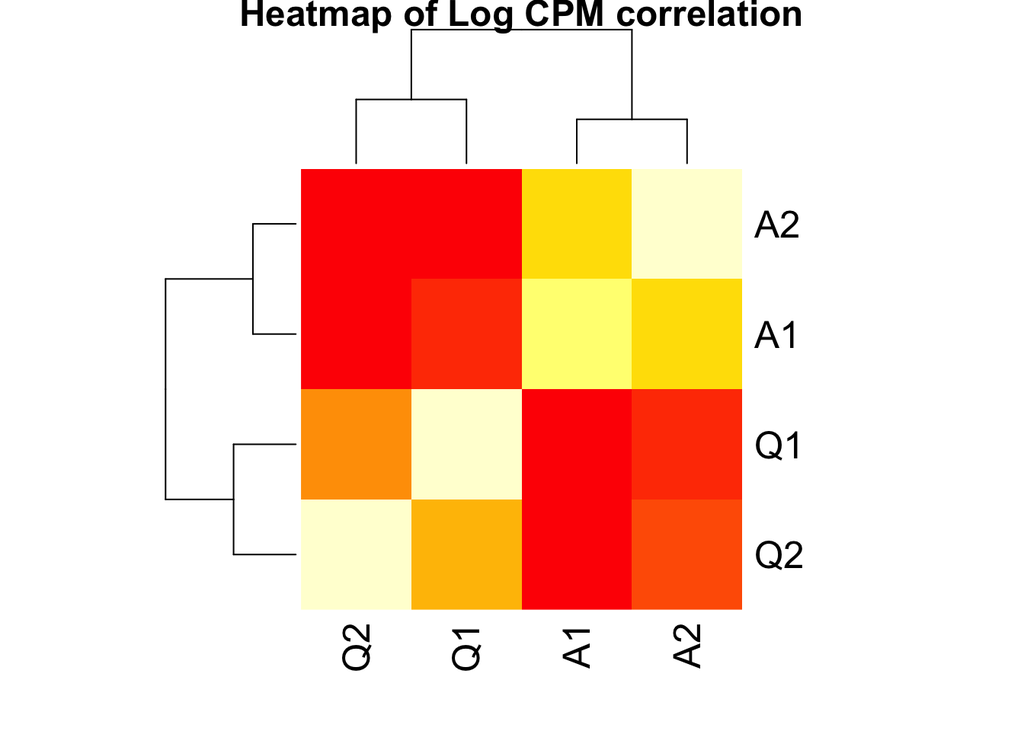

```r
cpm_log <- cpm(cds, log = TRUE)  #recalculate cpm after cleaning up data
heatmap(cor(cpm_log), main="Heatmap of Log CPM correlation", margins=c(5,5))
```

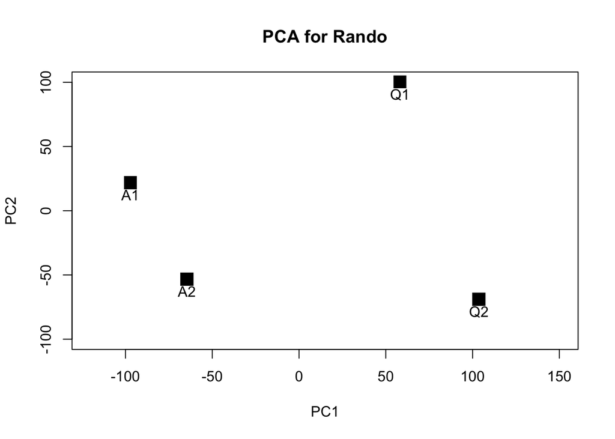

```r
#Another method to view the relationships between samples is principal components
#analysis (PCA).
pca <- prcomp(t(cpm_log), scale.=TRUE)
plot(pca$x[, 1], pca$x[, 2], pch = ".", cex=15, xlab = "PC1", ylab = "PC2", xlim=c(-120,150),ylim=c(-100,100), main="PCA for Rando")
text(pca$x[, 1], pca$x[, 2], labels = colnames(cpm_log), pos=1)
```

```r
summary(pca)
```

```
## Importance of components:
##                           PC1     PC2     PC3       PC4
## Standard deviation     96.185 77.7407 53.0082 3.122e-13
## Proportion of Variance  0.511  0.3338  0.1552 0.000e+00
## Cumulative Proportion   0.511  0.8448  1.0000 1.000e+00
```

[figure not shown]

```r
#finally a variation on PCA with plotMDS
plotMDS(cds, top=500, main="plotMDS of top 100 genes", col=as.numeric(cds$samples$group), pch=24)
legend("bottomleft", as.character(unique(cds$samples$group)), col=1:2, pch=24)
```

# Normalization factors and dispersion

```r
cds<- calcNormFactors(cds)
cds$samples
```

```
##    group  lib.size norm.factors
## A1   Act 129190347    0.9304073
## A2   Act 149484585    0.9254770
## Q1 Quies 115928475    1.2735767
## Q2 Quies  73925809    0.9118768
```

To estimate dispersion, we need a design matrix. Here I defined it without a control group, so that we wouldn’t have an intersect column.

```r
design <- model.matrix(~0+group, data=cds$samples)
colnames(design) <- levels(cds$samples$group) #assign groups as colnames
design
```

```
##    Act Quies
## A1   1     0
## A2   1     0
## Q1   0     1
## Q2   0     1
## attr(,"assign")
## [1] 1 1
## attr(,"contrasts")
## attr(,"contrasts")$group
## [1] "contr.treatment"
```

```r
cds <- estimateDisp(cds, design)
cds #now we have trended and tag wise dispersion in the object
```

```
## An object of class "DGEList"
## $counts
##            A1    A2    Q1   Q2
## A1BG-AS1  318   137   271   32
## A2M      2392 15501 19939 9312
## A2M-AS1   354   105  1134   94
## A2ML1      96    19    44   56
## A4GALT    113   136   738   32
## 18100 more rows ...
##
## $samples
##    group  lib.size norm.factors
## A1   Act 129190347    0.9304073
## A2   Act 149484585    0.9254770
## Q1 Quies 115928475    1.2735767
## Q2 Quies  73925809    0.9118768
##
## $common.dispersion
## [1] 0.5778128
##
## $trended.dispersion
## [1] 0.8465638 0.3050293 0.7496586 0.9654146 0.8183438
## 18100 more elements ...
##
## $trend.method
## [1] "locfit"
##
## $AveLogCPM
## [1]  0.6057053  6.6623646  1.6936620 -0.9592118  0.9232052
## 18100 more elements ...
##
## $span
## [1] 0.2894137
##
## $tagwise.dispersion
## [1] 0.7507044 0.3850085 0.7818134 0.8895538 0.8432698
## 18100 more elements ...
##
## $prior.df
## [1] 4.799249
##
## $prior.n
## [1] 2.399625
```

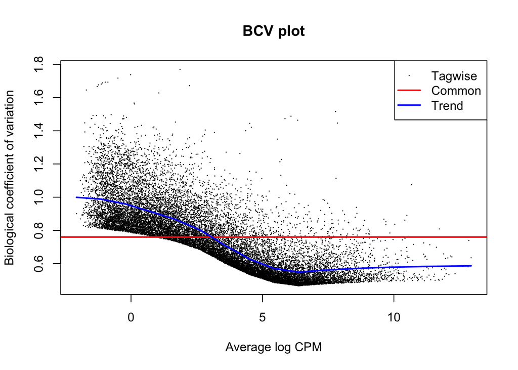

```r
plotBCV(cds, main="BCV plot")
```

# Exact test: Quiescent vs Activated

```r
et <- exactTest(cds, pair=c("Act","Quies"))
etp<- topTags(et, n=10)
etp
```

```
## Comparison of groups:  Quies-Act
##               logFC   logCPM       PValue          FDR
## FOSB      14.048477 9.683507 2.983691e-25 5.401973e-21
## FOLR1     -9.524020 6.580848 8.665390e-21 7.844345e-17
## MYL4      -8.330882 6.413726 2.521274e-18 1.148479e-14
## TULP2      9.276040 5.323456 2.537374e-18 1.148479e-14
## CD24      -9.517135 8.047045 4.025876e-18 1.457770e-14
## FLJ22447 -10.355041 6.853519 1.921842e-17 5.799157e-14
## HSPB3     -8.281207 6.616528 2.261802e-17 5.849991e-14
## APOD       8.883302 5.716815 5.657601e-17 1.280386e-13
## SPARCL1    8.713644 9.977173 1.072149e-16 2.156807e-13
## MYBPH    -12.528429 9.700575 2.699770e-16 4.887934e-13
```

```r
cds.DE <- decideTestsDGE(et, adjust.method="BH", p.value=0.05)
summary(cds.DE)
```

```
##    [,1]
## -1   981
## 0  15779
## 1   1345
```

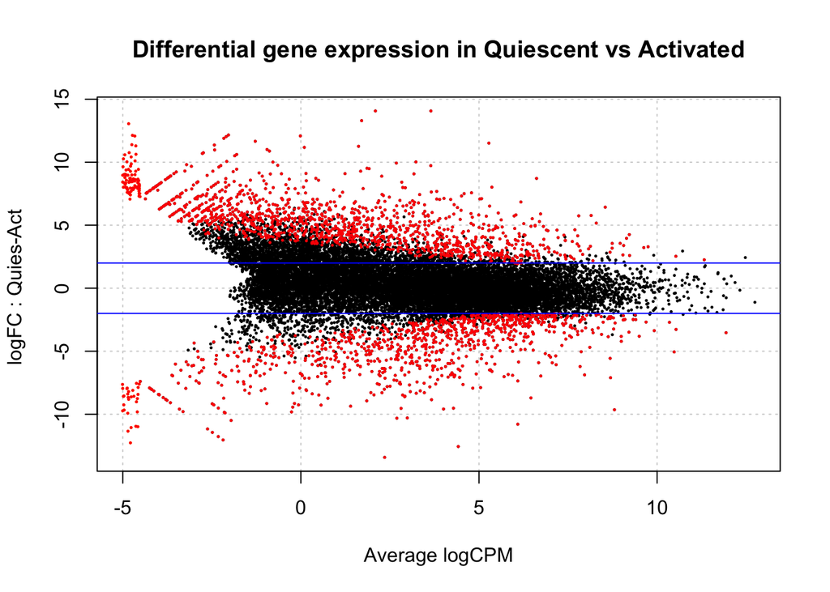

```r
de.genes <- rownames(cds)[as.logical(cds.DE)]
plotSmear(cds, de.tags = de.genes, main="Differential gene expression in Quiescent vs Activated")
abline(h = c(-2, 2), col = "blue")
```

```r
cds$samples$group <- relevel(cds$samples$group, ref="Quies") #relevel to get Quies as the ref group
design2 <- model.matrix(~group, data=cds$samples) #we use a new design with the Quiescent group as the reference level
design2
```

```
##    (Intercept) groupAct
## A1           1        1
## A2           1        1
## Q1           1        0
## Q2           1        0
## attr(,"assign")
## [1] 0 1
## attr(,"contrasts")
## attr(,"contrasts")$group
## [1] "contr.treatment"
```

```r
fit <- glmFit(cds, design2) #build the generalized linear model used for DE testing
lrt<- glmLRT(fit)
lrt.tbl <- topTags(lrt, n=10) # Make a table of results
lrt.tbl
```

```
## Coefficient:  groupAct
##               logFC   logCPM        LR       PValue          FDR
## FOSB     -14.048477 9.683507 110.45880 7.774453e-26 1.407565e-21
## FOLR1      9.524020 6.580848  89.05815 3.833760e-21 3.470511e-17
## TULP2     -9.276040 5.323456  78.23624 9.142586e-19 5.326976e-15
## MYL4       8.330882 6.413726  77.73742 1.176907e-18 5.326976e-15
## CD24       9.517135 8.047045  76.89749 1.800658e-18 6.520182e-15
## FLJ22447  10.355041 6.853519  74.31851 6.647712e-18 2.005947e-14
## HSPB3      8.281207 6.616528  73.31364 1.106010e-17 2.860615e-14
## APOD      -8.883302 5.716815  71.83486 2.339814e-17 5.295292e-14
## SPARCL1   -8.713644 9.977173  70.31182 5.063339e-17 1.018575e-13
## MYBPH     12.528429 9.700575  68.93996 1.015073e-16 1.837789e-13
```

```r
cds.DE2 <- decideTestsDGE(lrt, adjust.method="BH", p.value = 0.05)
summary(cds.DE2)
```

```
##    [,1]
## -1  1608
## 0  15408
## 1   1089
```

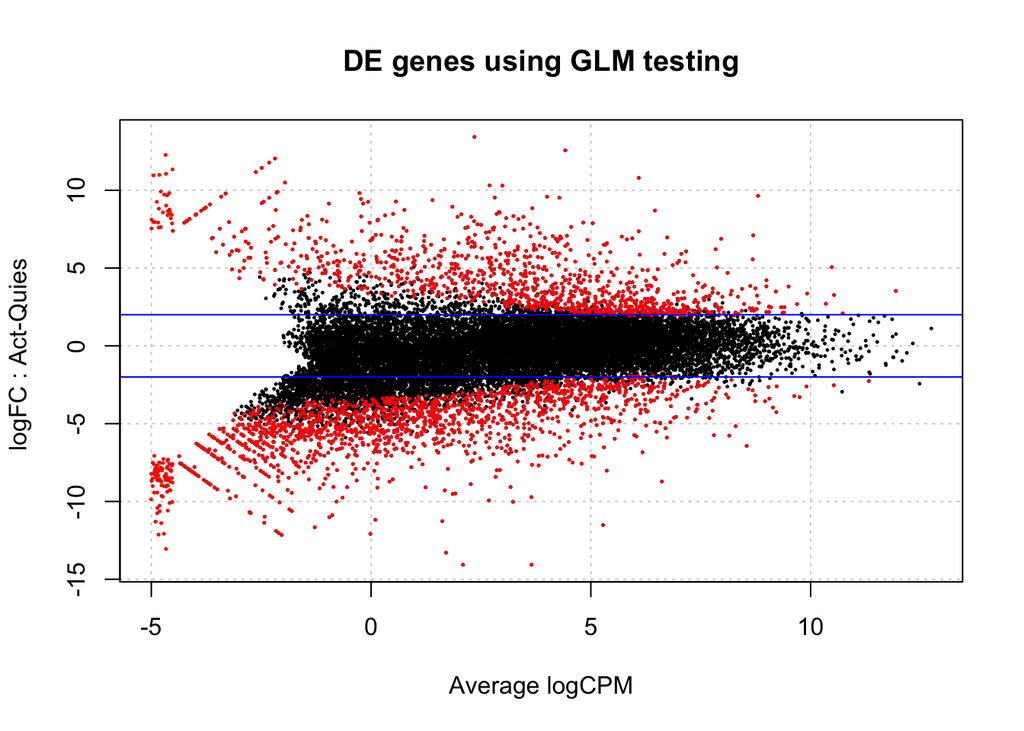

```r
de.genes2 <- rownames(cds)[as.logical(cds.DE2)]
plotSmear(cds, de.tags=de.genes2, main="DE genes using GLM testing")
abline(h = c(-2, 2), col = "blue")
```

```r
top <- rownames(etp) #for glm
cpm(cds)[top,]
```

```
##                    A1          A2           Q1           Q2
## FOSB     8.319493e-02   0.1084250 2.314462e+03 9.744370e+02
## FOLR1    1.613482e+02 220.8471668 2.641493e-01 2.521835e-01
## MYL4     1.757410e+02 164.0469496 5.892560e-01 4.598640e-01
## TULP2    1.331119e-01   0.1228816 9.052869e+01 6.939496e+01
## CD24     7.080720e+02 348.2609398 8.127669e-01 6.230416e-01
## FLJ22447 2.796181e+02 182.4069078 8.127669e-02 2.818521e-01
## HSPB3    1.743266e+02 216.7270187 7.585825e-01 4.895327e-01
## APOD     2.329458e-01   0.2096216 1.386174e+02 7.126409e+01
## SPARCL1  3.860245e+00   5.7176090 1.578779e+03 2.443465e+03
## MYBPH    2.414916e+03 912.6778602 4.605679e-01 8.900594e-02
```

```r
et.Tbl <- et$table
exact.DE <- rownames(et.Tbl)[et.Tbl$PValue <= 0.05 ]
length(exact.DE) #how many genes are significantly DE
```

```
## [1] 4747
```

```r
length(exact.DE)/nrow(et.Tbl) * 100 # Percentage of total genes
```

```
## [1] 26.21928
```

[figure not shown]

```r
hist(et.Tbl[exact.DE[1:1000],"logCPM"], xlab="Log CPM", xlim=c(-5,15),col="red", freq=FALSE, main="Top 100 DE genes - exactTest")
```

```r
lrt.Tbl <- lrt$table
glm.DE <- rownames(lrt.Tbl)[lrt.Tbl$PValue <= 0.05 ]
length(glm.DE) #how many genes are significantly DE
```

```
## [1] 5053
```

```r
length(glm.DE)/nrow(lrt.Tbl) * 100 # Percentage of total genes
```

```
## [1] 27.90942
```

[figure not shown]

```r
hist(lrt.Tbl[glm.DE[1:1000],"logCPM"], xlab="Log CPM", xlim=c(-5,15),col="red", freq=FALSE, main="Top 100 DE genes - GLM")
```

Now how about a volcano plot:

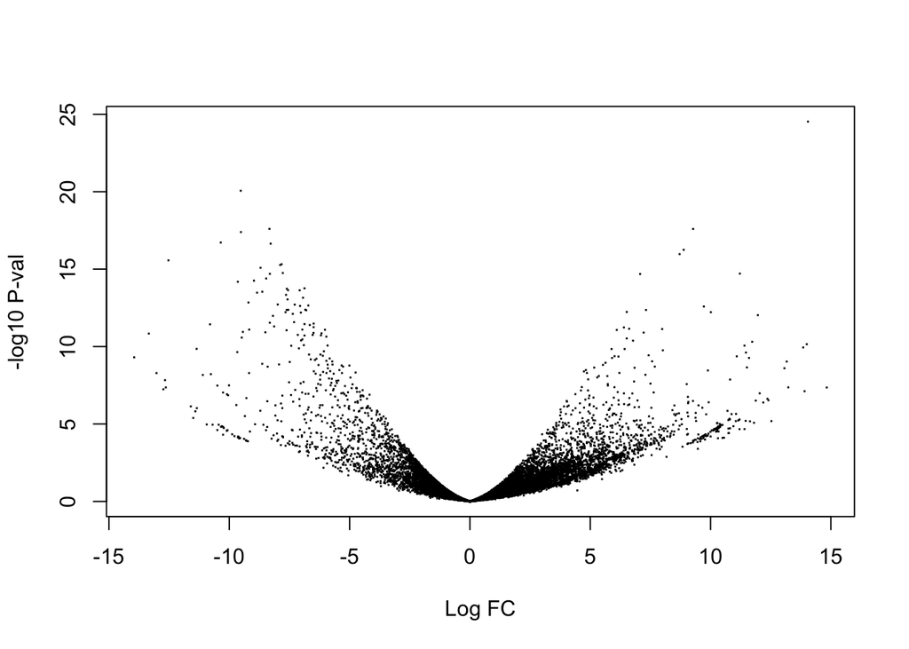

```r
plot(et.Tbl$logFC, -log10(et.Tbl$PValue), pch=15, cex=0.2, xlab="Log FC", ylab="-log10 P-val")
```

```r
library("ggplot2")
sum(abs(et.Tbl$PValue <= 0.05 & et.Tbl$logFC >1)) #the number of genes above this cutoff
```

```
## [1] 2885
```

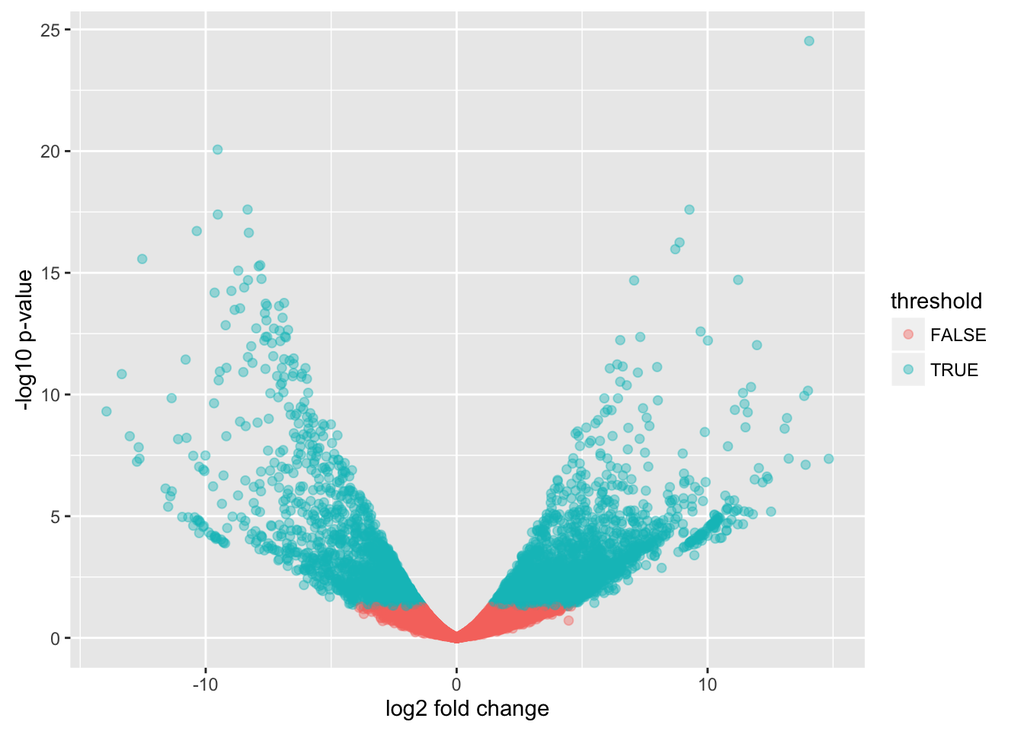

```r
et.Tbl$threshold = as.factor(abs(et.Tbl$logFC) > 1 & et.Tbl$PValue < 0.05)
#Construct the plot
g = ggplot(data=et.Tbl, aes(x=logFC, y=-log10(PValue), colour=threshold)) + geom_point(alpha=0.4, size=1.75) + xlab("log2 fold change") + ylab("-log10 p-value")
g
```